# Parametric Tests

Mark Dunning. Original materials by Materials by Deepak Parashar, Sarah Dawson and Sarah Vowler

Last modified: 18 Nov 2016

# Tests for continuous variables: T-tests

# Statistical tests - continuous variables

- t-test:
  - *One-sample t-test*
    - (e.g. $H_0$: mean=5)
  - *Independent two-sample t-test*
    - (e.g. $H_0$: mean of group A = group B)
  - *Paired two-sample t-test*
    - (e.g. $H_0$: mean difference between pairs = 0)
    - (e.g. before and after treatment)

# T-distributions

- We will be computing a test statistic and comparing to a t-distribution with a particular shape
  - the shape of the curve depends on the “degrees of freedom” (number of observations - 1)
  - as n increases, the curve becomes more like the normal distribution
  - the [central limit theorem](https://en.wikipedia.org/wiki/Central_limit_theorem) for those curious enough
  - whereabouts the statistic lies on the curve will give the “p-value”
  - the total area under the curve adds up to 1.

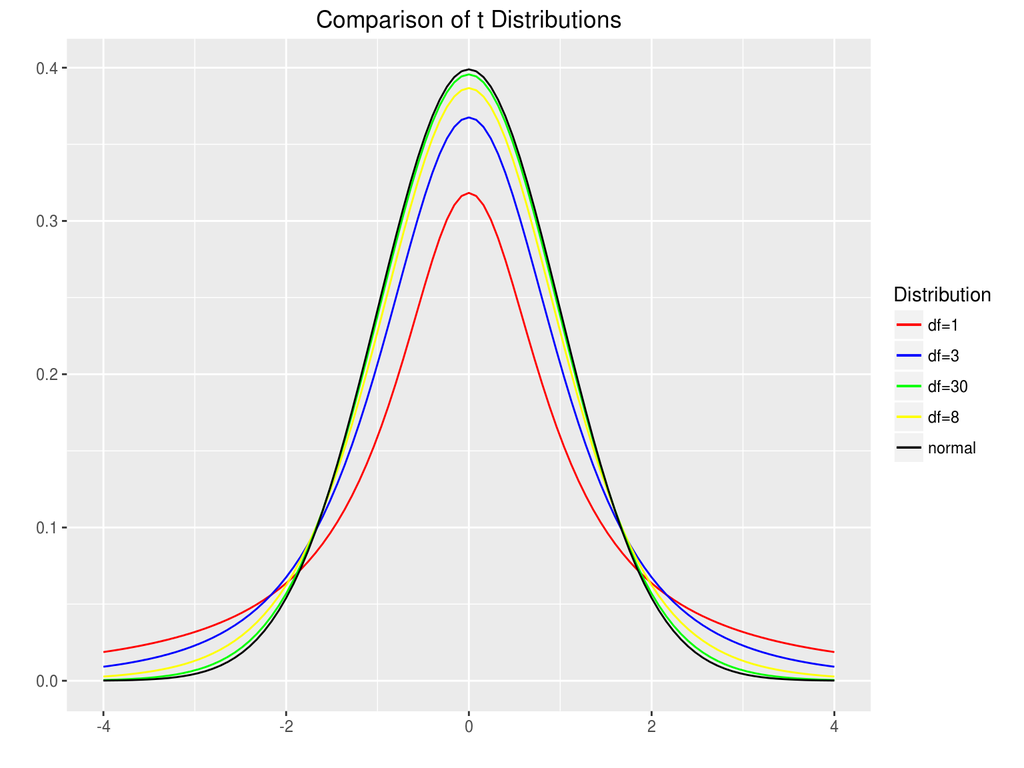

# One-sample t-test: does mean = X?

- The Genomics Core is suspicious that their microarrays are failing quite a lot
- Published data suggests that the microarray failure rate for a particular supplier is 2.1%.
- **Genomics Core want to know if this holds true in their own lab?**
- This test can be performed online using our “shiny” app:-
  - http://bioinformatics.cruk.cam.ac.uk/stats/OneSampleTest/
  - you’ll see these data upon loading the site

# One-sample t-test: does mean = X?

- Null hypothesis, $H_0$:
  - Mean monthly failure rate = 2.1%
- Alternative hypothesis: $H_1$:
  - Mean monthly failure rate $\ne$ 2.1%
- Tails: *two-tailed*
  - we are looking at either or an increase or decrease from 2.1
- Either *reject* or *do not reject* the null hypothesis - *Never accept the alternative hypothesis*

# One sample t-test; the data

- See the *Data Input* tab on the shiny app

```
+----+-----------+----------------------+
|    | Month     | Monthly.failure.rate |
+====+===========+======================+
| 1  | January   | 2.90                 |
+----+-----------+----------------------+
| 2  | February  | 2.99                 |
+----+-----------+----------------------+
| 3  | March     | 2.48                 |
+----+-----------+----------------------+
| 4  | April     | 1.48                 |
+----+-----------+----------------------+
| 5  | May       | 2.71                 |
+----+-----------+----------------------+
| 6  | June      | 4.17                 |
+----+-----------+----------------------+
| 7  | July      | 3.74                 |
+----+-----------+----------------------+
| 8  | August    | 3.04                 |
+----+-----------+----------------------+
| 9  | September | 1.23                 |
+----+-----------+----------------------+
| 10 | October   | 2.72                 |
+----+-----------+----------------------+
| 11 | November  | 3.23                 |
+----+-----------+----------------------+
| 12 | December  | 3.40                 |
+----+-----------+----------------------+
```

# One-sample t-test; key assumptions

- Observations are independent
  - unless we have good reason to suspect otherwise, we usually assume this
- Observations are normally distributed
  - check the graphs…
  - *Data Distribution* tab
  - numerical summaries available here too

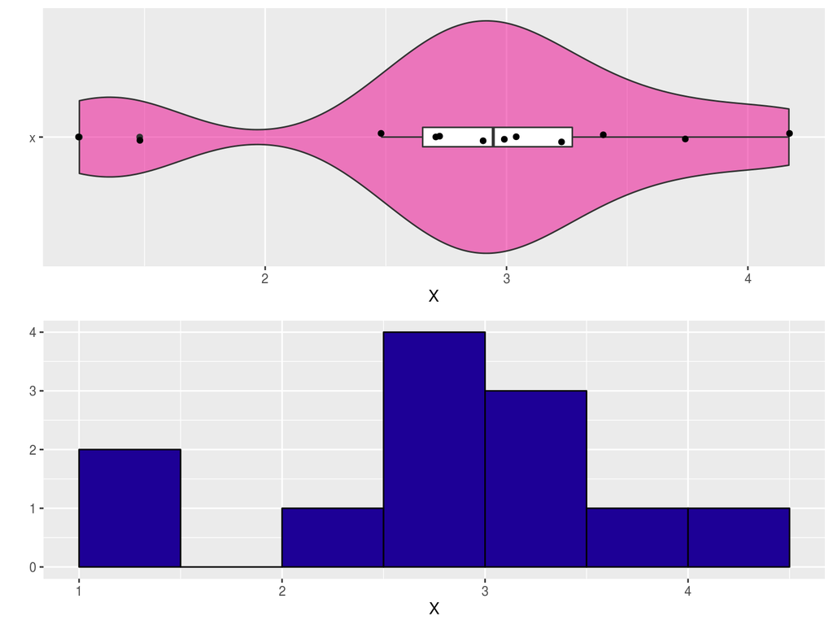

# One-sample t-test; results

mean = $(2.9 + \dots + 3.40) / 12$ = 2.841

Standard deviation = 0.837

Hypothesised Mean = 2.1

n = 12

Test statistic:
$$t_{n-1} = t_{11} = \frac{\bar{x} - \mu_0} {s.d. / \sqrt{n}} = \frac{2.84 - 2.10}{s.e.(\bar{x})}$$

# One-sample t-test; results

Test statistic:= 3.065

- We need to compare to the t distribution with 11 degrees of freedom
- Having decided a p-value cut-off of 0.05, we can know which values on the x-axis will give an area of 0.05
  - shown in yellow
  - two symmetrical areas as we’re doing a *two-tailed* test
- See *Statistical Analysis* tab

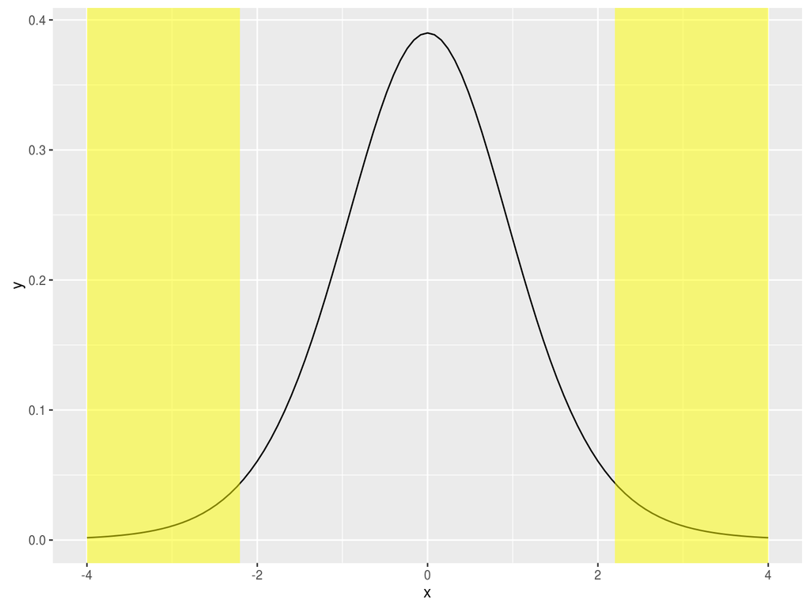

# One-sample t-test; results

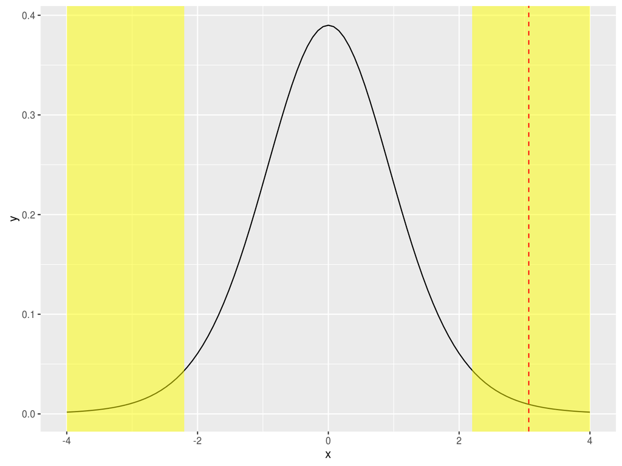

# One-sample t-test; results

Conclusion: *Reject* $H_0$

- There is *evidence* that mean monthly failure rate $\ne$ 2.1%
- The mean monthly failure rate of microarrays in the Genomics core is 2.84 (95% CI: 2.30, 3.37).
- It is not equal to the hypothesized mean proposed by the company of 2.1.
- t=3.07, df=11, p=0.01

# One-sample t-test; Exercise

- Work through Exercise 1 of the practical; The effect of disease on height

# Two-sample t-test

- Two types of two-sample t-test:
- Independent:
  - e.g.the weight of two different breeds of mice
  - males versus females, smokers versus non-smokers
- Paired
  - e.g. a measurement of disease at two different parts of the body in the same patient / animal
  - e.g. measurements before and after treatment for the same individual

# Independent two-sample t-test: Does the mean of group A = mean of group B?

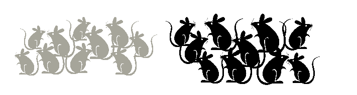

- e.g. research question: 40 male mice (20 of breed A and 20 of breed B) were weighed at 4 weeks old
- Does the weight of 4-week old male mice depend on breed?

# Independent two-sample t-test: Does the mean of group A = mean of group B?

- Null hypothesis, $H_0$
  - mean weight of breed A = mean weight of breed B
- Alternative hypothesis, $H_1$
  - mean weight of breed B $\ne$ mean weight of breed B
- Tails: two-tailed
  - the tails on the distribution - not on the mice ;)
- Either *reject* or *do not reject* the null hypothesis - *never accept the alternative hypothesis*

# Independent two-sample t-test: the data

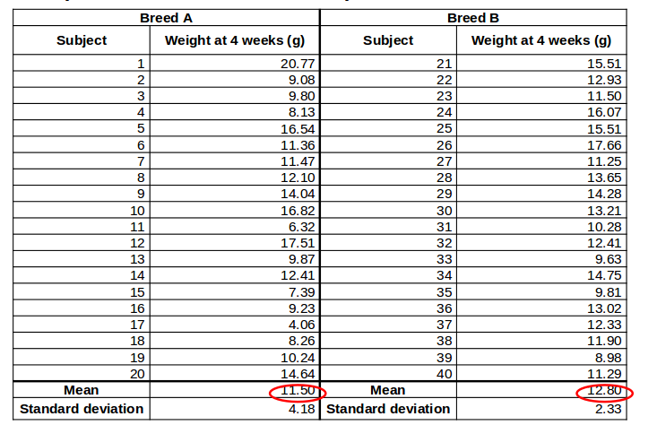

You can see these data in shiny

- http://bioinformatics.cruk.cam.ac.uk/stats/TwoSampleTest/

# Independent two-sample t-test: key assumptions

- Observations are independent
- Observations are normally-distributed

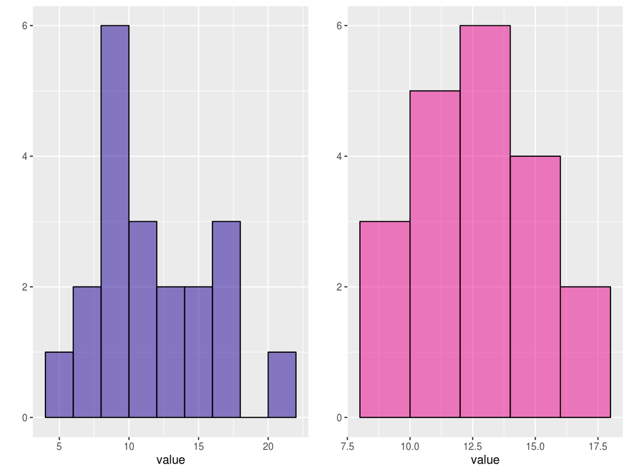

# Independent two-sample t-test: further considerations

- We have to check for “equal” variance in the two comparison groups
  - having different variances doesn’t mean we can’t do the test
  - Use “Welch’s correction” if variances are different
  - alters the t-statistic and degrees of freedom
  - there are statistical tests to test for equal variance, but safer to eye-ball the data

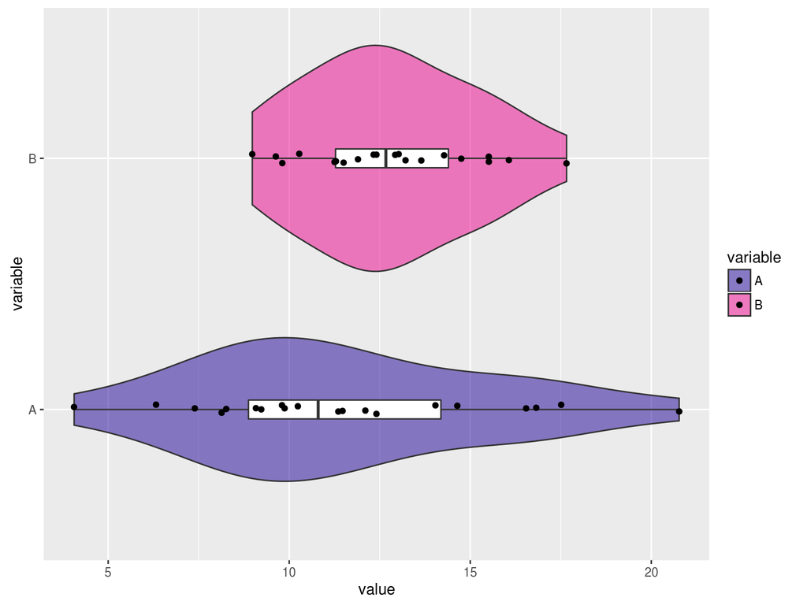

# Independent two-sample t-test: result

$t_{df} = \frac{\bar{X_A} - \bar{X_B}}{s.e.(\bar{X_A} - \bar{X_B})}$ = -1.21

df = 29.78 (with Welch’s correction)

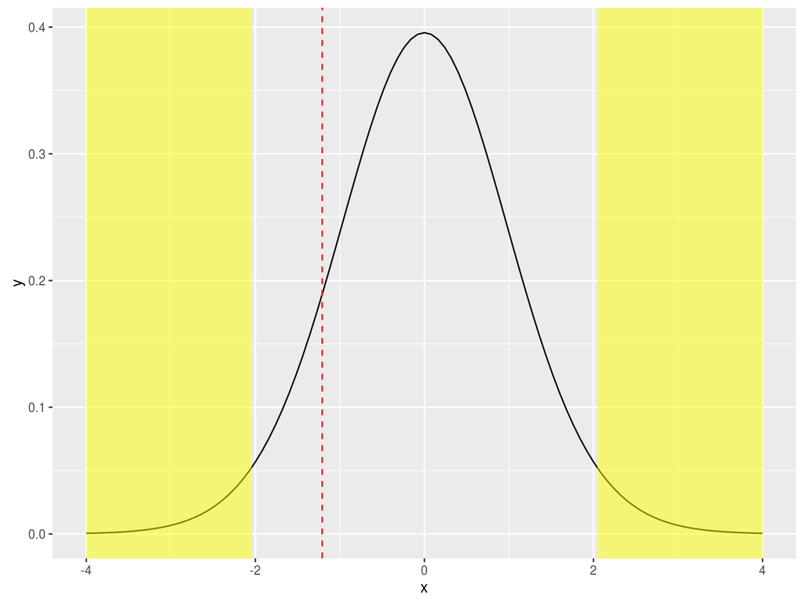

P-value: 0.24

*Do not reject* $H_0$

(No evidence that mean weight of breed A $\ne$ mean weight of breed B)

# Independent two-sample t-test: result

- The difference in mean weight between the two breeds is -1.30 (95% CI: -3.48, 0.89)
  - [NB as this is negative, breed B mice tend to be bigger than breed A].
- There is *no evidence* of a difference in weights between breed A and breed B.
- t=-1.21, df= 29.78 (Welch’s correction), p=0.24

# Paired two-sample t-test: Does the mean difference = 0?

- e.g. Research question: 20 patients with ovarian cancer were studied using MRI imaging. Cellularity was measured for each patient at two sites of disease.
  - cellularity is a measure of how much tumour is present at a particular location
- Does the cellularity differ between two different sites of disease?

# Paired two-sample t-test: Does the mean difference = 0?

- Null hypothesis, $H_0$:
  - Cellularity at site A = Cellularity at site B
- Alternative hypothesis, $H_1$
  - Cellularity at site A $\ne$ Cellularity at site B
- Tails: two-tailed
- Either *reject* or *do not reject* the null hypothesis - *never accept the alternative hypothesis*

# Paired two-sample t-test; null hypothesis

- $H_0$; Cellularity at site A = Cellularity at site B
  - *or*
- $H_0$: Cellularity at site A - Cellularity at site B = 0
- In other words, we are effectively doing a *one-sample* test on the differences

# Paired two-sample t-test; the data

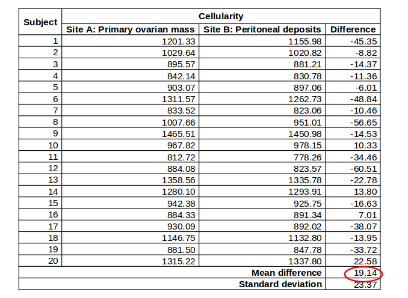

- Same shiny app as for previous example
- Now load data from `Manual/Paired two-sample t-test.csv`
- Tick the tick-box in *Are your samples paired?*

# Paired two-sample t-test; key assumptions

- Observations are independent
- The *paired differences* are normally-distributed
  - as we’re effectively doing a one-sample test on these differences
- Don’t need to check if the variances are similar

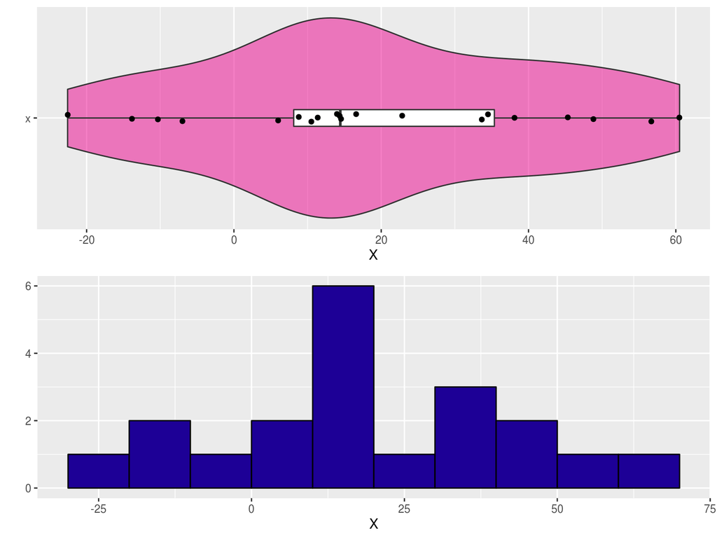

# Paired two-sample t-test; results

$t_{n-1} = t_{19} = \frac{\bar{X_{A-B}}}{s.e.(\bar{X_{A-B}})} =$ 3.66

df = 19

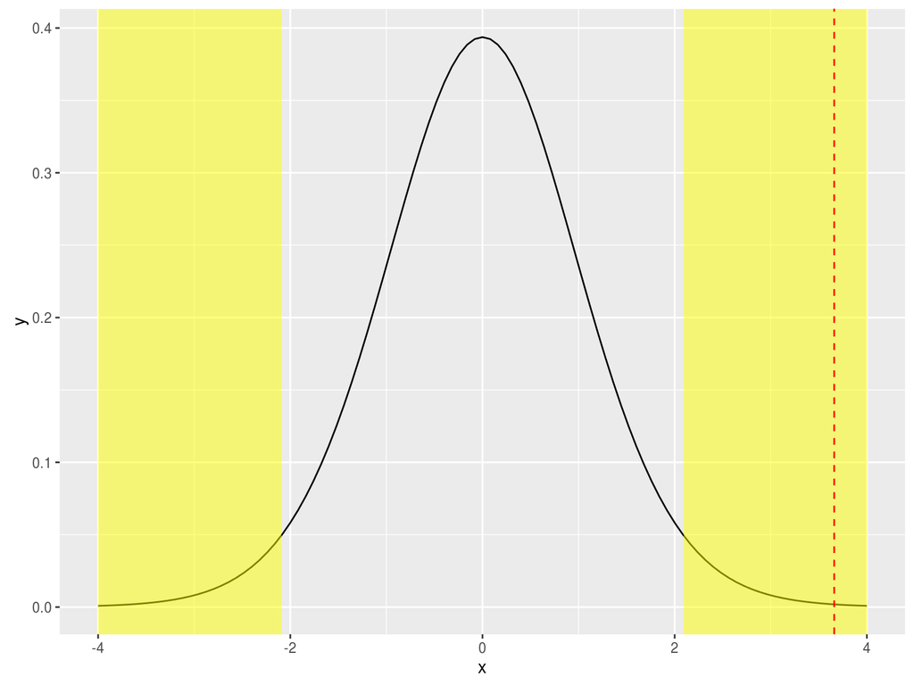

P-value: 0.002

*Reject* $H_0$ (evidence that cellularity at Site A $\ne$ site B)

# Paired two-sample t-test; results

- The difference in cellularity between the two sites is 19.14 (95% CI: 8.20, 30.08).
- There is evidence of a difference in cellularity between the two sites.
- t=3.66, df=19, p=0.002.

# Summary - continuous variables

- One-sample t-test
  - Use when we have one group.
- Independent two-sample t-test
  - Use when we have two independent groups. A Welch correction may be needed if the two groups have different spread.
- Paired two-sample t-test
  - Use when we have two non-independent groups.
- Non-parametric tests
  - Used when we cannot assume normality.
- More than two-groups?
  - Need a method such as ANOVA
  - which we don’t cover in this course :(

# Summary - t-test

- Turn scientific question to null and alternative hypothesis
- Think about test assumptions
- Calculate summary statistics
- Carry out t-test if appropriate

# Practical

- Complete the t-test practical
  - Parametric tests only!
- We will start the next lecture after lunch
  - 13:30